# Description

### Course STAT565 Bayesian Analysis

#### Semester Fall 2017

#### Content Project: Introduction to Dirichlet Process

#### Author Enes Dilber

```r
options(warn=-1)
library(ggplot2)
library(repr)
library(mvtnorm)
library(MCMCpack)
library(LaplacesDemon)
library(psych)
library(ggforce)
library(RCurl)

script = getURL("https://raw.githubusercontent.com/enesdilber/565/master/userFunctionsforProject.R", ssl.verifypeer = FALSE)
eval(parse(text = script))
```

# 1 Introduction to Nonparametric Bayesian Methods

- $\textbf{Bayesian}:$
  - $ P(parameters|data) \propto P(data|parameters)P(parameters) $
- $\textbf{Non-parametric}:$
  - Not-finite parameters, unbounded/growing/infinite number of parameters

```r
n = 200
Mu = rbind(c(2, 5),
           c(5, 1),
           c(0,1),
           c(8,2))
x = gen_BVN(n, Mu, mixp = c(0.25, 0.25, 0.25, 0.25))
df = data.frame(0, 0, 0, 0)
colnames(df) = c("X1", "X2", "c", "k")
```

## 1.1 Clustering

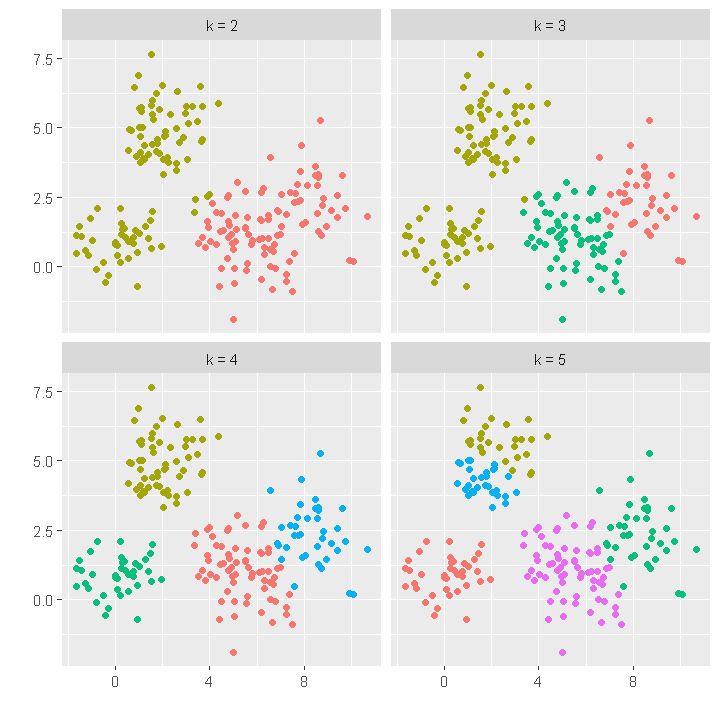

```r
n = 200
Mu = rbind(c(2, 5),
           c(5, 1),
           c(0,1),
           c(8,2))
x = gen_BVN(n, Mu, mixp = c(0.25, 0.25, 0.25, 0.25))
df = data.frame(0, 0, 0, 0)
colnames(df) = c("X1", "X2", "c", "k")

clusters = sapply(2:5, function(k) kmeans(x, k)$cluster)
for(i in 1:dim(clusters)[2]){
    cur = cbind(x, clusters[,i], paste("k =",as.character(i+1)))
    colnames(cur) = c("X1", "X2", "c", "k")
    df = rbind(df, cur)
}
df = df[-1,]

options(repr.plot.width=6, repr.plot.height=6)
sp = ggplot(df, aes(X1, X2)) + geom_point(aes(color = as.factor(c))) + theme(legend.position = "none")
sp + facet_wrap(~as.factor(k), ncol=2) + xlab("") + ylab("")
```

Trying to find the latent structure at data.

Lets do not consider $\sigma^2_k$ for simplicity. Here is our Gaussian Mixture Model:

- k = 2 (2 clusters)
- Prior of each cluster means: $\mu_k \overset{iid}\sim N(\mu_0, \Sigma) $
- Prior percentage of points from first cluster $p_1 \sim Beta(a_1, a_2)$, $ \ p_2 = 1 - p_1$
- Probability of each data point belongs to $cluster \ 1$ or $2$ is $z_n \overset{iid}\sim Categorical(p_1, p_2)$
- Distribution of each data point $x_n \overset{iid}\sim N(\mu_{z_n}, \Sigma) $

## 1.2 Drichlet Distribution

It is the multivariate version of $Beta$ distribution. Lets compare Beta and Drichlet:

```r
set.seed(108)
n = 10000
X = rbeta(n, 3, 7)
X = cbind(X, 1-X)
"Beta(3,7)"
unname(round(colMeans(X), 3))

Y = rdirichlet(n, c(3,2,5))
"Dirichlet(3,2, 5)"
round(colMeans(Y), 3)
```

'Beta(3,7)'

1. 0.301

2. 0.699

'Dirichlet(3,2, 5)'

1. 0.299

2. 0.201

3. 0.5

```r
X = rdirichlet(n, c(3,2,5))
"Dirichlet(3,2, 5)"
round(colMeans(X), 3)
```

'Dirichlet(3,2, 5)'

1. 0.301

2. 0.199

3. 0.501

Those are expected selection probability of each clusters. Cluster $Z_i$ will be selected with probability $p_i$.

```r
set.seed(108)
n = 1000
k = 100
X = sapply(c(0.1, 1, 10), function(x) RDr(n, k, x))
df = data.frame(alpha = as.factor(rep(c("0.1", "1", "10"), each =  n)),
                x = rep(1:n, by = 3),
                y = as.vector(X))
```

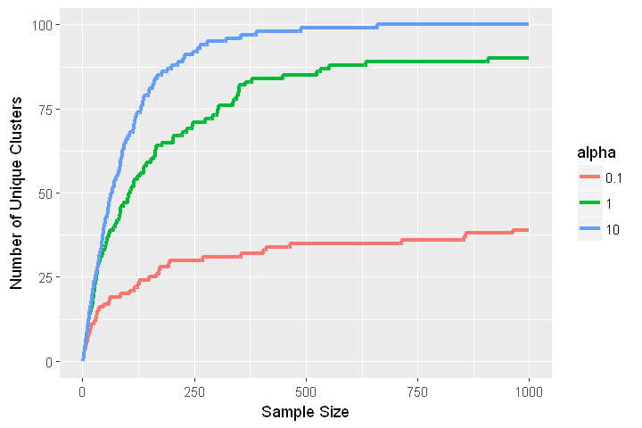

```r
options(repr.plot.width=6, repr.plot.height=4)
ggplot(df, aes(x, y)) + geom_line(aes(colour = alpha), size=1.4)+
    ylab("Number of Unique Clusters") + xlab("Sample Size") +
    xlim(c(0, n)) + ylim(c(0, k))
```

It is important to set k, because in small k`s we reach maximum clusters altough there is still need for clusters. But increasing k comes with a cost. However in Drichlet Process we are going to think as $\infty$ therefore we are never going to hit the limit.

## 1.3 Stick Breaking

Intiution behind Stick Breaking:

```r
set.seed(108)
print(mean(rbeta(10000, 2, 1)))
print(colMeans(rdirichlet(10000, c(2, 0.3, 0.2, 0.5))))
```

```
[1] 0.6657097
[1] 0.66491330 0.10122814 0.06887498 0.16498358
```

Choosin $K = \infty $ in Drichlet

$$p_{1:k} \sim Drichlet(a_{1:k})$$ is equivalent to: $$V_1 \sim Beta(a_1, \sum_{k=2}^{K}a_k) \ \ \ \ \ p_1 = V_1$$ $$V_2 \sim Beta(a_2, \sum_{k=3}^{K}a_k) \ \ \ \ \ p_2 = (1-p_1) V_2$$ $$.$$ $$.$$ $$.$$ $$V_{k-1} \sim Beta(a_{k-1}, a_k) \ \ \ \ \ p_{k-1} = (1-\sum_{i = 1}^{k-2}p_i)V_{k-1}$$ $$p_k = 1-\sum_{i = 1}^{k-1}p_i$$

```r
V = numeric(); p = numeric()

V[1] = rbeta(n = 1, shape1 = 10, shape2 = 10) ; p[1] = V[1]
for(i in 2:10){
    a = 10*(1/2)^(i-1)
    V[i] = rbeta(n = 1, shape1 = a, shape2 = a)
    p[i] = V[i]*(1-sum(p))

    }
p
```

1. 0.334462889097725

2. 0.49001830192982

3. 0.124166414253596

4. 0.000219394645280643

5. 0.0353649328573662

6. 0.00491874006811837

7. 0.00120529966393896

8. 0.00964402748415527

9. 0

10. 0

That's definetly gave the solution but keep adding $a's$ waste of time. Instead this objective could be obtained by a simpler equation. $$V_1 \sim Beta(a_1, b_1) \ \ \ \ \ p_1 = V_1$$ $$V_2 \sim Beta(a_2, b_2) \ \ \ \ \ p_2 = (1-p_1) V_2$$ $$.$$ $$.$$ $$.$$ $$V_k \sim Beta(a_k, b_k) \ \ \ \ \ p_k = (1-\sum_{i = 1}^{k-1}p_i)V_{k-1}$$

By seting $a_i = 1$ and $b_i = \alpha$

GEM distribution:

$$p = (p_1, p_2, ...) \sim GEM(\alpha) $$

```r
alphas = c(0.1, 1, 10, 100)
X = lapply(alphas, function(x) colMeans(rGEM(10, x)))
```

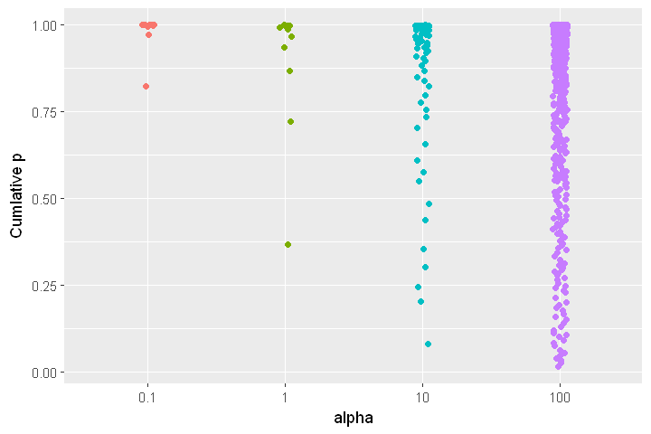

```r
label = c()
probs = c()
for(i in 1:length(alphas)){
    n = length(X[[i]])

    c_label = rep(as.character(alphas[i]), n)
    label = c(label, c_label)

    c_probs = X[[i]]
    for(j in 2:n){
        c_probs[j] = c_probs[j-1] + c_probs[j]
    }

    probs = c(probs, c_probs)

}

df = data.frame(l = label, p = probs)
ggplot(df, aes(l, p)) + theme(legend.position = "none")+
  geom_jitter(width = 0.05, aes(colour = l)) + xlab("alpha") + ylab("Cumlative p")
```

## Dirichlet Process

```r
p = rGEM(1, 5) #drawing the GEM
x = rnorm(length(p))
counts = data.frame(theta = x, prob = t(p))
sum(p)
```

1

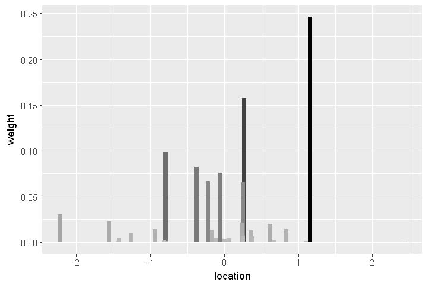

```r
ggplot(counts, aes(x, prob)) + theme(legend.position = "none") + scale_color_continuous(low = "grey", high = "black")+
  geom_segment(aes(xend = x, yend = 0, color = prob), size = 2, lineend = "butt") + ylab("weight") +xlab("location")
```

In general: $$\large{G = \sum^{\infty}_{i=1}\pi_i \delta_{\phi_k}}$$

- $\pi \sim GEM(\alpha)$
- $\phi_k \overset{iid}\sim G_0$
- $G \sim DP(\alpha, G_0)$
- $\alpha$ is parameter of stick-breaking, controls sparsity
- $G_0$ base measure that gives location of the atoms Draw from G is a draw with location at $\phi$ space and direction $\pi$. The important thing is direction is independent from location.

## Example: Let's draw from $G \sim DP(\alpha, N_2(\mu_0, \Sigma_0))$

Let:  
$p = (p_1, p_2, ...)\sim GEM(\alpha)$ Draw from GEM  
$\mu_k \overset{iid} \sim N(\mu_0, \Sigma_0), k=1,2,...$ Draw from Cluster Location

Sampling from $G$ is **equivelent to** these steps:  
$z_n \overset{iid} \sim Categorical(p) $ *This data point blogs to selected cluster*  
$\mu_n^* = \mu_{z_n} $, *$n^{th}$ data point will be around the mean indexed by $z_n$*  
$i.e. \mu_n^* \overset{iid}\sim G$  
Since it is a discrete distribution, the clusters will be repeated a lot and will get data points around some clusters. At the end we sample data point, from:  
$x_n \overset{indep}\sim N(\mu_n^*, \Sigma) $

```r
n = 1000; mu = c(0,0); Sigma = diag(2);

a = c(1, 5, 10, 40)

df = data.frame(0, 0, 0, 0)
colnames(df) = c("X1", "X2", "c", "alpha")

for(i in 1:length(a)){
    alpha = a[i]
    p = rGEM(1, alpha, mySeed = 108)
    z = rcat(n, p[1:length(p)])
    m = rmvnorm(length(p), mu, Sigma)

    x = matrix(0, n, 2)
    for(i in 1:n){
        x[i,] = rmvnorm(1, m[z[i],], Sigma*0.02)
    }
    x = as.data.frame(x)
    x$c = as.factor(z)
    x$alpha = paste("alpha =", alpha)
    colnames(x) = c("X1", "X2", "c", "alpha")
    df = rbind(df, x)
}
df = df[-1,]
df$alpha = as.factor(df$alpha)
df$alpha = factor(df$alpha, levels(df$alpha)[c(1,4,2,3)])
```

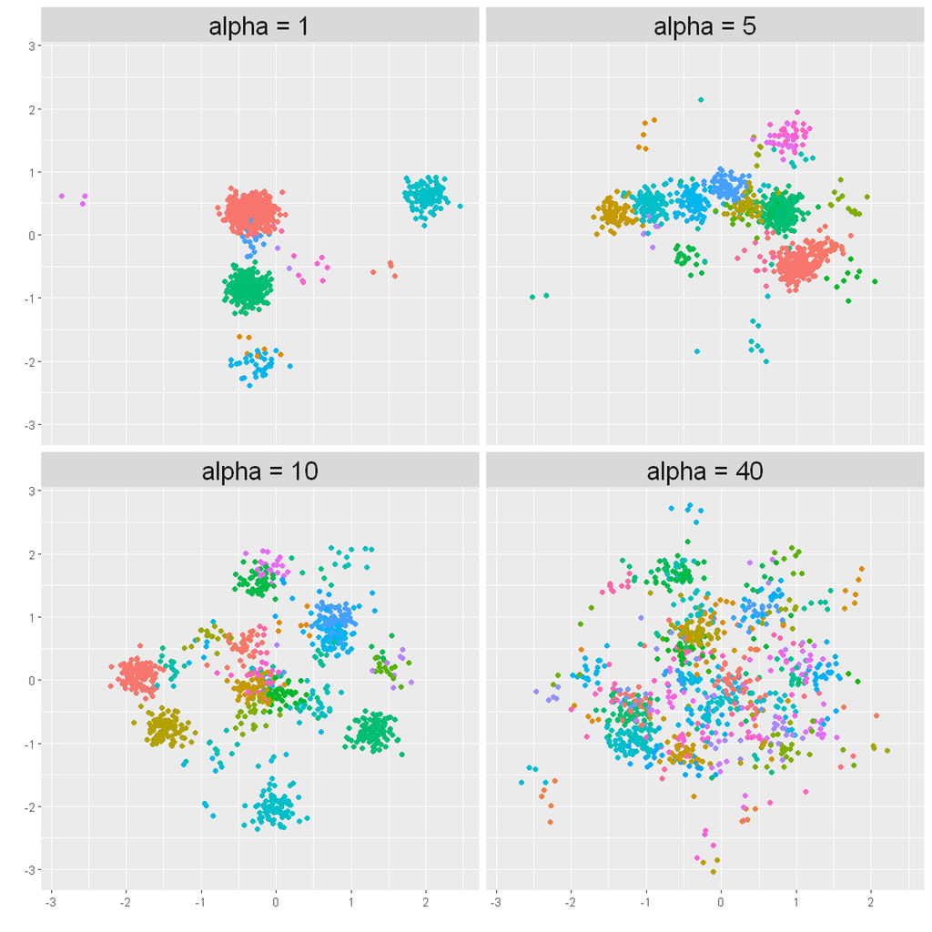

```r
options(repr.plot.width=10, repr.plot.height=10)
ggplot(df, aes(X1, X2, c)) + geom_point(aes(color = c)) + theme(legend.position = "none")+
    facet_wrap(~as.factor(alpha), ncol=2) + xlab("") + ylab("") +
    theme(strip.text.x = element_text(size=20), strip.text.y = element_text(size=20))
```

# A Gibbs Sampler Example

```r
x = gen_BVN(n, Mu, mixp = c(0.25, 0.25, 0.25, 0.25), mySeed = 1) #sample our syntetic data

myX = data.frame(X1= x[,1],X2 = x[,2])

# run a CRP Gibbs sampler with 100 iterations and initialized all data points in the same cluster
GMMfit = ex6_crp_gibbs(data=data.matrix(x), sd=1, sd0 = 3 ,initz=rep(1,n), MI = 100, mySeed = 1)
```

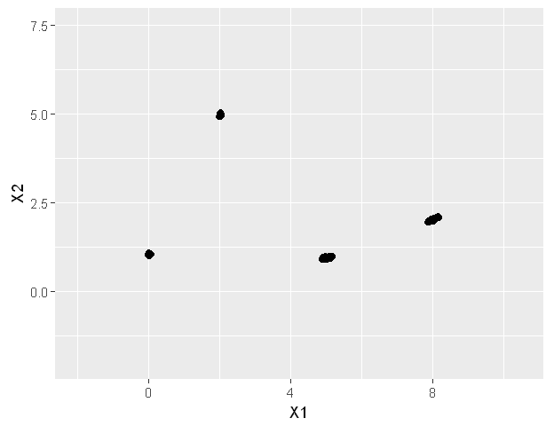

```r
df = GMMfit
df = data.frame(df[-(1:90000),]) #discard burn-in

options(repr.plot.width=5.2, repr.plot.height=4)
ggplot(data = df, aes(X3, X4))+geom_point() +coord_fixed() + xlab("X1") + ylab("X2") +
  xlim(c(-2, 10.5)) +ylim(c(-2, 7.5))
```

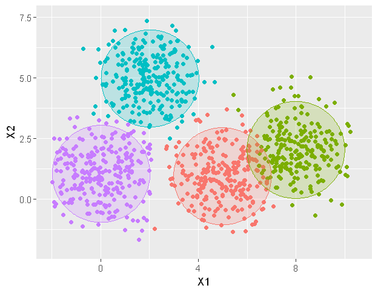

```r
#below code is just for illustration purposes
#to find mean of each cluster, we cluster gibbs returns and get aggregated expectatios
k = 4
kk = kmeans(df[,c(3,4)], k, nstart = 4)
df$clusters = kk$cluster
points = data.frame(cbind(df$X2, dummy.code(df$clusters)))
points = aggregate(points[,-1], list(points$V1), mean)
myX$cluster = as.factor(apply(points[,-1], 1,  which.max))

#draw standard deviation circles
circles = data.frame(
  x0 = kk$centers[,1],
  y0 =  kk$centers[,2],
  r = rep(2, k),
  l = as.factor(1:k)
)

options(repr.plot.width=5.2, repr.plot.height=4)
ggplot() + geom_point(data = myX, aes(X1, X2, color = cluster)) + theme(legend.position = "none") +
  geom_circle(data =circles, aes(x0 = x0, y0 =y0, r = r, fill = l, color = l), alpha = 0.2) +
  xlim(c(-2, 10.5)) +ylim(c(-2, 7.5))
```